# PAC_1

### 3.2

```r
# info més rellevant
head(Aids2)
```

|  | state | sex | diag | death | status | T.categ | age |
| --- | --- | --- | --- | --- | --- | --- | --- |
| 1 | NSW | M | 10905 | 11081 | D | hs | 35 |
| 2 | NSW | M | 11029 | 11096 | D | hs | 53 |
| 3 | NSW | M | 9551 | 9983 | D | hs | 42 |
| 4 | NSW | M | 9577 | 9654 | D | haem | 44 |
| 5 | NSW | M | 10015 | 10290 | D | hs | 39 |
| 6 | NSW | M | 9971 | 10344 | D | hs | 36 |

```r
summary(Aids2)
```

```
##    state      sex           diag           death       status      T.categ
##  NSW  :1780   F:  89   Min.   : 8302   Min.   : 8469   A:1082   hs     :2465
##  Other: 249   M:2754   1st Qu.:10163   1st Qu.:10672   D:1761   blood  :  94
##  QLD  : 226            Median :10665   Median :11235            hsid   :  72
##  VIC  : 588            Mean   :10584   Mean   :10990            other  :  70
##                        3rd Qu.:11103   3rd Qu.:11504            id     :  48
##                        Max.   :11503   Max.   :11504            haem   :  46
##                                                                 (Other):  48
##       age
##  Min.   : 0.00
##  1st Qu.:30.00
##  Median :37.00
##  Mean   :37.41
##  3rd Qu.:43.00
##  Max.   :82.00
##
```

Amb el summary podem fer-nos una ràpida idea de què compon el nostre dataset ja que trobem les variables i un breu resum de quines categories son les més freqüents

# SECCIÓ 2

## Exercici 4

### 4.1

```r
# Definiu dos data frame d'acord amb la variable Gender per als valors Male i Female
library(dplyr)
male_data <- sleep_health %>% filter(Gender == "Male")
female_data <- sleep_health %>% filter(Gender == "Female")
# Exportar CSV
write.csv(male_data, file = "sleep_health_m.csv", row.names = FALSE)
write.csv(female_data, file = "sleep_health_f.csv", row.names = FALSE)
```

### 4.2

```r
# mitjana d'edat de les dones l'ocupació de les quals sigui Nurse:
mean(female_data$Age[female_data$Occupation == 'Nurse'])
```

```
## [1] 51.79452
```

```r
mean(sleep_health$Age[sleep_health$Occupation == 'Nurse' & sleep_health$Gender == 'Female'])
```

```
## [1] 51.79452
```

```r
# Qualitat son i stress level del grup
mean(sleep_health$Stress.Level[sleep_health$Occupation == 'Nurse' & sleep_health$Gender == 'Female'])
```

```
## [1] 5.547945
```

```r
mean(sleep_health$Quality.of.Sleep[sleep_health$Occupation == 'Nurse' & sleep_health$Gender == 'Female'])
```

```
## [1] 7.369863
```

Tenint en compte que els valors de Qualitat del son i de Estress van del 1 al 10: Les enfermeres tenen uns nivells normals d’estress, ja que depenent del torn i de la especialització pot ser una feina estressant o molt tranquila, per això la mitjana acaba balancejant-se en un valor mitjà.

Les enfermeres tenen relativament una bona qualitat del son tot i que encara hi ha marge de millora per a alguns individus.

### 4.3

```r
#sleep_max
sleep_max <- sleep_health %>% filter(Sleep.Duration == max(sleep_health$Sleep.Duration))
#sleep_min
sleep_min <- sleep_health %>% filter(Sleep.Duration == min(sleep_health$Sleep.Duration))
```

Hi ha 13 individus que dormen un maxim de 8.5 h.

Hi ha només 2 individus que dormen el minim de 5.8.

Tots els individus dels dos datasets (min i max) son ‘Female’.

Els individus sleep min son científiques relativament joves, deuen estar acabant el posdoctorat jeje, tenen apnea del son i alts nivells d’estrés entre altres, factors que disminueixen activament el temps i la qualitat del son.

Els individus sleep max son enginyieres de mitjana edat-avançada amb molt bona qualitat del son, baixos nivells d’estrés i no presenten transtorns del son.

### 4.4

```r
x<-sleep_health$Occupation[sleep_health$Quality.of.Sleep < mean(sleep_health$Quality.of.Sleep) & sleep_health$BMI.Category == 'Overweight']
table(x)
```

```
## x
##        Accountant          Engineer            Lawyer           Manager
##                 6                 2                 2                 1
##             Nurse       Salesperson         Scientist Software Engineer
##                33                32                 4                 1
##           Teacher
##                33
```

Els valors més significatius son les professions de profesor, venedor i enfermer, ja que hi ha més de 30 individus al dataset amb aquestes caracterísitques de qualitat del son inferior a la mitjana i sobrepés.

Pot ser que les enfermeres siguin propenses a tenir poca qualitat del son degut als torns que afecten al ritme circadià de l’organisme, que també està correlacionat amb el sobrepés

En el cas dels profesors pot ser perquè aquesta es una feina bastant estressant (sobretot a educació secundaria obligatoria) i molt sedentària, que també afavoreix al sobrepés

Salesperson es possible que també sigui una feina molt sendentaria però actualment desconec el motiu per el qual podrien tenir una qualitat del son inferior a la mitjana

### 4.5

```r
selected_columns <- sleep_health[, c("Gender", "Age", "Occupation", "Stress.Level")]
# Convertim a matriu
matrix <- as.matrix(selected_columns)
```

Aquest tipus de format seria interessant per a fer transformacions espacials sobre les dades o volguessim calcular la relació espacial entre variables, com angle, distancia, etc entre els vectors (variables).

# SECCIÓ 3

## Exercici 5

### 5.1

#### Diagrama de caixes Sleep_duration i Stress_level

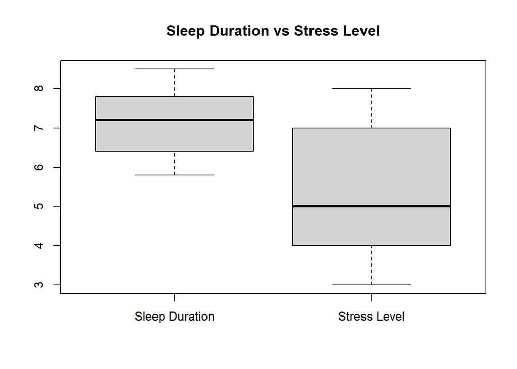

S’observa que la distribució de les hores de son dels pacients es troba majoritàriament entre les 6 i les 8h, en canvi hi ha una major variació pels valors de nivells de estrés, ja que la distribució de valors es molt més àmplia, trobant-se la mitjana al 5.

### 5.2

#### Model de regressió per a les dues variables anteriors i un diagrama de punts que ajusta al model

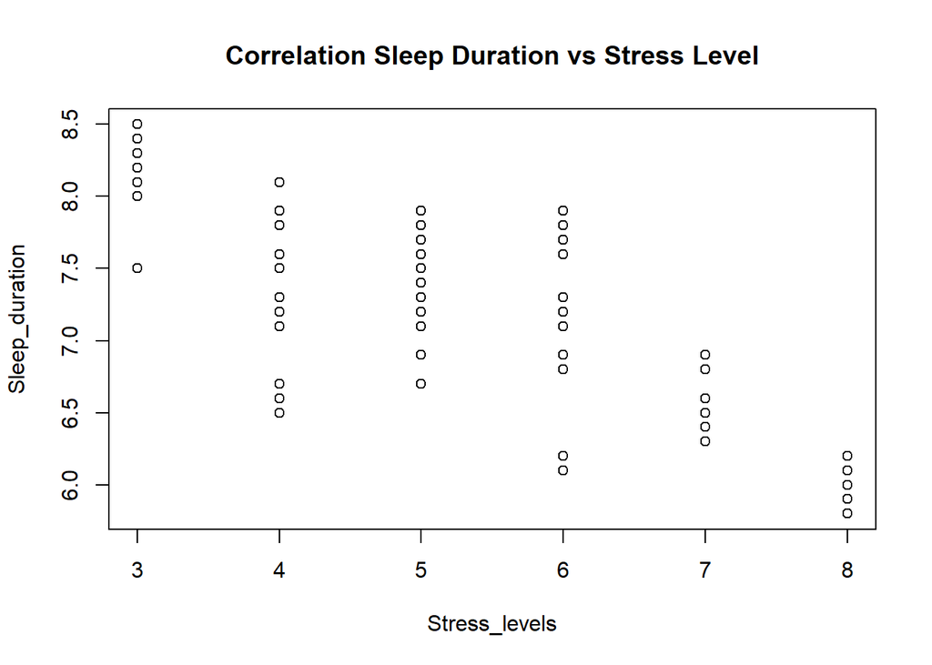

```r
modelo<-lm(Stress_levels~Sleep_duration, data=sleep_health)  #model amb ajust de R^2 = 0.6578
summary(modelo)
```

```
##
## Call:
## lm(formula = Stress_levels ~ Sleep_duration, data = sleep_health)
##
## Residuals:
##     Min      1Q  Median      3Q     Max
## -2.5283 -0.6343  0.1099  0.6525  2.0040
##
## Coefficients:
##                Estimate Std. Error t value Pr(>|t|)
## (Intercept)    18.28552    0.48545   37.67   <2e-16 ***
## Sleep_duration -1.80880    0.06765  -26.74   <2e-16 ***
## ---
## Signif. codes:  0 '***' 0.001 '**' 0.01 '*' 0.05 '.' 0.1 ' ' 1
##
## Residual standard error: 1.04 on 372 degrees of freedom
## Multiple R-squared:  0.6578, Adjusted R-squared:  0.6568
## F-statistic:   715 on 1 and 372 DF,  p-value: < 2.2e-16
```

Podem observar com a mesura que augmenten els nivells d’estres va disminuint les hores de son del pacient de forma progressiva, trobant un punt d’inflexió important en els nivells d’estres superiors a 6 on la durada del son es veu disminuida per sota de 7h.

### 5.3

#### Matriu de correlació del conjunt de dades sleep_health

```
##                Sleep.Duration Stress.Level
## Sleep.Duration       1.000000    -0.811023
## Stress.Level        -0.811023     1.000000
```

Es pot afirmar que hi ha una gran correlació entre aquestes dues variables ja que el valor es molt proper a 1 al ser el vaor -0.811 indica una correlació negativa, quan major es l’estres menor es la durada del son.

### 5.4

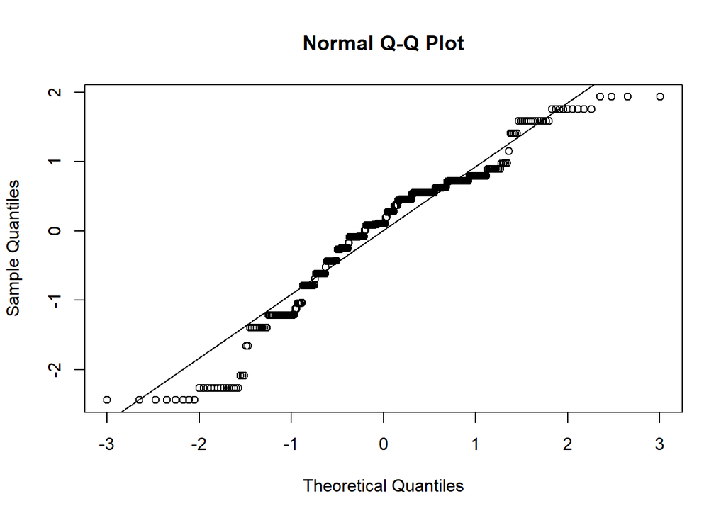

```r
residuos<-rstandard(modelo) # residuos estándares del modelo ajustado
qqnorm(residuos) # gráfico de cuantiles de los residuos estandarizados
qqline(residuos) # dibujamos la reta en el gráfico anterior
```

## Exercici 6

### 6.1

#### Resum estadístic de sleep_health

```r
summary(sleep_health)
```

```
##    Person.ID         Gender               Age         Occupation
##  Min.   :  1.00   Length:374         Min.   :27.00   Length:374
##  1st Qu.: 94.25   Class :character   1st Qu.:35.25   Class :character
##  Median :187.50   Mode  :character   Median :43.00   Mode  :character
##  Mean   :187.50                      Mean   :42.18
##  3rd Qu.:280.75                      3rd Qu.:50.00
##  Max.   :374.00                      Max.   :59.00
##  Sleep.Duration  Quality.of.Sleep Physical.Activity.Level  Stress.Level
##  Min.   :5.800   Min.   :4.000    Min.   :30.00           Min.   :3.000
##  1st Qu.:6.400   1st Qu.:6.000    1st Qu.:45.00           1st Qu.:4.000
##  Median :7.200   Median :7.000    Median :60.00           Median :5.000
##  Mean   :7.132   Mean   :7.313    Mean   :59.17           Mean   :5.385
##  3rd Qu.:7.800   3rd Qu.:8.000    3rd Qu.:75.00           3rd Qu.:7.000
##  Max.   :8.500   Max.   :9.000    Max.   :90.00           Max.   :8.000
##  BMI.Category       Blood.Pressure       Heart.Rate     Daily.Steps
##  Length:374         Length:374         Min.   :65.00   Min.   : 3000
##  Class :character   Class :character   1st Qu.:68.00   1st Qu.: 5600
##  Mode  :character   Mode  :character   Median :70.00   Median : 7000
##                                        Mean   :70.17   Mean   : 6817
##                                        3rd Qu.:72.00   3rd Qu.: 8000
##                                        Max.   :86.00   Max.   :10000
##  Sleep.Disorder
##  Length:374
##  Class :character
##  Mode  :character
##
##
##
```

```r
str(sleep_health)
```

```
## 'data.frame':    374 obs. of  13 variables:
##  $ Person.ID              : int  1 2 3 4 5 6 7 8 9 10 ...
##  $ Gender                 : chr  "Male" "Male" "Male" "Male" ...
##  $ Age                    : int  27 28 28 28 28 28 29 29 29 29 ...
##  $ Occupation             : chr  "Software Engineer" "Doctor" "Doctor" "Sales Representative" ...
##  $ Sleep.Duration         : num  6.1 6.2 6.2 5.9 5.9 5.9 6.3 7.8 7.8 7.8 ...
##  $ Quality.of.Sleep       : int  6 6 6 4 4 4 6 7 7 7 ...
##  $ Physical.Activity.Level: int  42 60 60 30 30 30 40 75 75 75 ...
##  $ Stress.Level           : int  6 8 8 8 8 8 7 6 6 6 ...
##  $ BMI.Category           : chr  "Overweight" "Normal" "Normal" "Obese" ...
##  $ Blood.Pressure         : chr  "126/83" "125/80" "125/80" "140/90" ...
##  $ Heart.Rate             : int  77 75 75 85 85 85 82 70 70 70 ...
##  $ Daily.Steps            : int  4200 10000 10000 3000 3000 3000 3500 8000 8000 8000 ...
##  $ Sleep.Disorder         : chr  "None" "None" "None" "Sleep Apnea" ...
```

### 6.2

#### Taules de freqüències realtives i absolutes de les variables Occupation i Sleep_duration

```r
freq_occ<-table(sleep_health$Occupation)
freq_occ
```

```
##
##           Accountant               Doctor             Engineer
##                   37                   71                   63
##               Lawyer              Manager                Nurse
##                   47                    1                   73
## Sales Representative          Salesperson            Scientist
##                    2                   32                    4
##    Software Engineer              Teacher
##                    4                   40
```

```r
prop.table(freq_occ)
```

```
##
##           Accountant               Doctor             Engineer
##          0.098930481          0.189839572          0.168449198
##               Lawyer              Manager                Nurse
##          0.125668449          0.002673797          0.195187166
## Sales Representative          Salesperson            Scientist
##          0.005347594          0.085561497          0.010695187
##    Software Engineer              Teacher
##          0.010695187          0.106951872
```

```r
freq_sleep<-table(sleep_health$Sleep.Duration)
freq_sleep
```

```
##
## 5.8 5.9   6 6.1 6.2 6.3 6.4 6.5 6.6 6.7 6.8 6.9 7.1 7.2 7.3 7.4 7.5 7.6 7.7 7.8
##   2   4  31  25  12  13   9  26  20   5   5   3  19  36  14   5   5  10  24  28
## 7.9   8 8.1 8.2 8.3 8.4 8.5
##   7  13  15  11   5  14  13
```

```r
prop.table(freq_sleep)
```

```
##
##         5.8         5.9           6         6.1         6.2         6.3
## 0.005347594 0.010695187 0.082887701 0.066844920 0.032085561 0.034759358
##         6.4         6.5         6.6         6.7         6.8         6.9
## 0.024064171 0.069518717 0.053475936 0.013368984 0.013368984 0.008021390
##         7.1         7.2         7.3         7.4         7.5         7.6
## 0.050802139 0.096256684 0.037433155 0.013368984 0.013368984 0.026737968
##         7.7         7.8         7.9           8         8.1         8.2
## 0.064171123 0.074866310 0.018716578 0.034759358 0.040106952 0.029411765
##         8.3         8.4         8.5
## 0.013368984 0.037433155 0.034759358
```

```r
#Taula creuada
cross_tab <- table(sleep_health$Occupation, sleep_health$Sleep.Duration)
cross_tab
```

```
##
##                        5.8 5.9  6 6.1 6.2 6.3 6.4 6.5 6.6 6.7 6.8 6.9 7.1 7.2
##   Accountant             0   0  0   0   0   0   0   2   4   0   0   0  10  19
##   Doctor                 0   0 18   9   6   0   0   0   0   0   0   0   0   0
##   Engineer               0   0  0   0   0   0   0   1   0   0   1   1   0   2
##   Lawyer                 0   0  0   0   0   0   0   0   0   0   0   1   6  11
##   Manager                0   0  0   0   0   0   0   0   0   0   0   1   0   0
##   Nurse                  0   1 13  15   4   0   2   2   0   0   0   0   1   0
##   Sales Representative   0   2  0   0   0   0   0   0   0   0   0   0   0   0
##   Salesperson            0   0  0   0   0  12   7  13   0   0   0   0   0   0
##   Scientist              2   0  0   0   2   0   0   0   0   0   0   0   0   0
##   Software Engineer      0   1  0   1   0   0   0   0   0   0   0   0   0   0
##   Teacher                0   0  0   0   0   1   0   8  16   5   4   0   2   4
##
##                        7.3 7.4 7.5 7.6 7.7 7.8 7.9  8 8.1 8.2 8.3 8.4 8.5
##   Accountant             0   0   0   0   0   0   0  2   0   0   0   0   0
##   Doctor                 2   0   0   5  14   9   4  0   2   2   0   0   0
##   Engineer               5   0   2   1   5  13   0  0   0   0   5  14  13
##   Lawyer                 7   5   0   4   5   6   2  0   0   0   0   0   0
##   Manager                0   0   0   0   0   0   0  0   0   0   0   0   0
##   Nurse                  0   0   1   0   0   0   1 11  13   9   0   0   0
##   Sales Representative   0   0   0   0   0   0   0  0   0   0   0   0   0
##   Salesperson            0   0   0   0   0   0   0  0   0   0   0   0   0
##   Scientist              0   0   0   0   0   0   0  0   0   0   0   0   0
##   Software Engineer      0   0   2   0   0   0   0  0   0   0   0   0   0
##   Teacher                0   0   0   0   0   0   0  0   0   0   0   0   0
```

Amb la taula de freqüencies creuades podem observar les hores que dorm el nombre de pacients que pertanyen a la mateixa professió. Observem que els doctors i les infermeres son de les persones que dormen més i menys, ja que aproximadament la meitat dormen per sota de 6.2hores i l’altra meitat dormen per sobre de 7.6 hores. Els enginyiers son els pacients que dormen el major nombre d’hores.

### 6.3

#### Histograma quality of sleep i diagrama de barres occupation

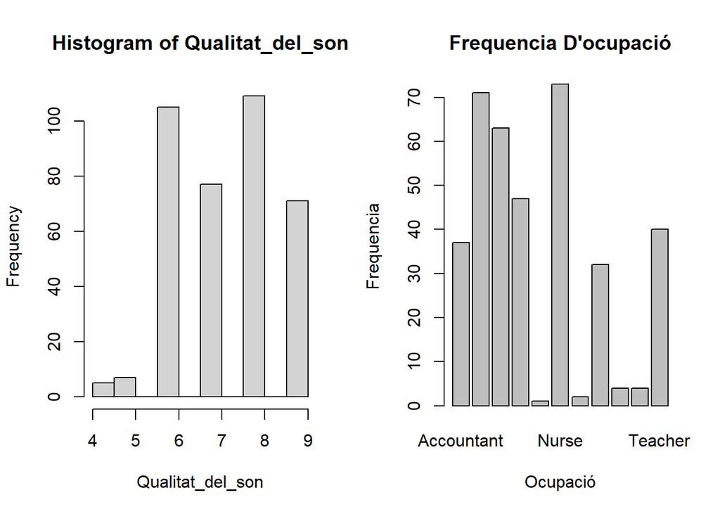

```r
par(mfrow = c(1, 2))
Qualitat_del_son <- sleep_health$Quality.of.Sleep
hist(Qualitat_del_son)
occupation_freq <- table(sleep_health$Occupation)
barplot(occupation_freq, main = "Frequencia D'ocupació", xlab = "Ocupació", ylab = "Frequencia")
```

### 6.4

#### Qplot amb ggplot2

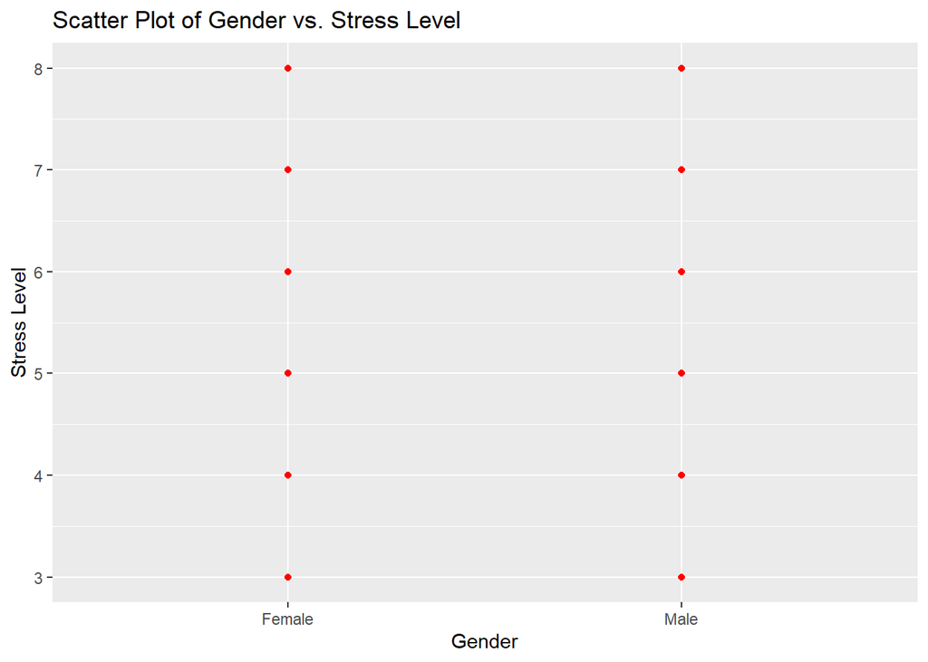

Trobem que tan homes com dones tenen uns nivells d’estrés semblants ja que els punts es distribueixen per tot el rang de la variable y en els dos gèneres